# Midterm Project

## Rishikesh Mane, Sai Kiran Samala, Anshmeet Singh Anand and Naveen

```r
install.packages('fasttime')
```

```r
library(dplyr)
library(lubridate)
```

```r
ibm_data <- read.csv('/Users/anshmeet/Desktop/hw2/IBM.csv')
msft_data <- read.csv('/Users/anshmeet/Desktop/hw2/MSFT.csv')
goog_data <- read.csv('/Users/anshmeet/Desktop/hw2/GOOG.csv')
amzn_data <- read.csv('/Users/anshmeet/Desktop/hw2/AMZN.csv')
aapl_data <- read.csv('/Users/anshmeet/Desktop/hw2/AAPL.csv')
fb_data <- read.csv('/Users/anshmeet/Desktop/hw2/FB.csv')
nflx_data <- read.csv('//Users/anshmeet/Desktop/hw2/NFLX.csv')
tsla_data <- read.csv('/Users/anshmeet/Desktop/hw2/TSLA.csv')
orcl_data <- read.csv('/Users/anshmeet/Desktop/hw2/ORCL.csv')
sap_data <- read.csv('/Users/anshmeet/Desktop/hw2/SAP.csv')
USD_JPY = read.csv('/Users/anshmeet/Desktop/hw2/JPY=X.csv')
```

```r
ibm_close <- ibm_data[, c('Date', 'Close', 'Adj.Close')]
ibm_close <- rename(ibm_close, 'IBM_Close' = 'Close','IBM_Adj.Close' =  'Adj.Close')
msft_close <- msft_data[, c('Date', 'Close', 'Adj.Close')]
msft_close <- rename(msft_close, 'MSFT_Close' = 'Close','MSFT_Adj.Close' =  'Adj.Close')
goog_close <- goog_data[, c('Date', 'Close', 'Adj.Close')]
goog_close <- rename(goog_close, 'GOOG_Close' = 'Close','GOOG_Adj.Close' =  'Adj.Close')
amzn_close <- amzn_data[, c('Date', 'Close', 'Adj.Close')]
amzn_close <- rename(amzn_close, 'AMZN_Close' = 'Close','AMZN_Adj.Close' =  'Adj.Close')
aapl_close <- aapl_data[, c('Date', 'Close', 'Adj.Close')]
aapl_close <- rename(aapl_close, 'AAPL_Close' = 'Close','AAPL_Adj.Close' =  'Adj.Close')
fb_close <- fb_data[, c('Date', 'Close', 'Adj.Close')]
fb_close <- rename(fb_close, 'FB_Close' = 'Close','FB_Adj.Close' =  'Adj.Close')
nflx_close <- nflx_data[, c('Date', 'Close', 'Adj.Close')]
nflx_close <- rename(nflx_close, 'NFLX_Close' = 'Close','NFLX_Adj.Close' =  'Adj.Close')
tsla_close <- tsla_data[, c('Date', 'Close', 'Adj.Close')]
tsla_close <- rename(tsla_close, 'TSLA_Close' = 'Close','TSLA_Adj.Close' =  'Adj.Close')
orcl_close <- orcl_data[, c('Date', 'Close', 'Adj.Close')]
orcl_close <- rename(orcl_close, 'ORCL_Close' = 'Close','ORCL_Adj.Close' =  'Adj.Close')
sap_close <- sap_data[, c('Date', 'Close', 'Adj.Close')]
sap_close <- rename(sap_close, 'SAP_Close' = 'Close','SAP_Adj.Close' =  'Adj.Close')
jpy_close <- USD_JPY[, c('Date', 'Close')]
jpy_close$Date = as.Date(jpy_close$Date)
nrow(jpy_close)
jpy_close <- rename(jpy_close, 'JPY_Close' = 'Close')
```

259

```r
stocks_data = merge(merge(merge(merge(merge(merge(merge(merge(merge(ibm_close, msft_close, by = 'Date'),goog_close, by = 'Date'), amzn_close, by='Date'), aapl_close, by='Date'), fb_close, by='Date'),
nflx_close, by='Date'), tsla_close, by='Date'), orcl_close, by='Date'), sap_close, by='Date')
stocks_data$Date = as.Date(stocks_data$Date)
```

```r
tail(stocks_data,15)
```

A data.frame: 15 × 21

|  | Date <date> | IBM_Close <dbl> | IBM_Adj.Close <dbl> | MSFT_Close <dbl> | MSFT_Adj.Close <dbl> | GOOG_Close <dbl> | GOOG_Adj.Close <dbl> | AMZN_Close <dbl> | AMZN_Adj.Close <dbl> | AAPL_Close <dbl> | ⋯ | FB_Close <dbl> | FB_Adj.Close <dbl> | NFLX_Close <dbl> | NFLX_Adj.Close <dbl> | TSLA_Close <dbl> | TSLA_Adj.Close <dbl> | ORCL_Close <dbl> | ORCL_Adj.Close <dbl> | SAP_Close <dbl> | SAP_Adj.Close <dbl> |
| --- | --- | --- | --- | --- | --- | --- | --- | --- | --- | --- | --- | --- | --- | --- | --- | --- | --- | --- | --- | --- | --- |
| 236 | 2018-12-07 | 119.34 | 109.77248 | 104.82 | 102.47753 | 1036.58 | 1036.58 | 1629.13 | 1629.13 | 42.1225 | ⋯ | 137.42 | 137.42 | 265.14 | 265.14 | 71.594 | 71.594 | 46.00 | 44.62671 | 100.72 | 97.95202 |
| 237 | 2018-12-10 | 121.13 | 111.41898 | 107.59 | 105.18561 | 1039.55 | 1039.55 | 1641.03 | 1641.03 | 42.4000 | ⋯ | 141.85 | 141.85 | 269.70 | 269.70 | 73.030 | 73.030 | 46.67 | 45.27669 | 101.90 | 99.09959 |
| 238 | 2018-12-11 | 120.89 | 111.19822 | 108.59 | 106.16327 | 1051.75 | 1051.75 | 1643.24 | 1643.24 | 42.1575 | ⋯ | 142.08 | 142.08 | 265.32 | 265.32 | 73.352 | 73.352 | 46.46 | 45.07297 | 101.56 | 98.76893 |
| 239 | 2018-12-12 | 121.16 | 111.44659 | 109.08 | 106.64233 | 1063.68 | 1063.68 | 1663.54 | 1663.54 | 42.2750 | ⋯ | 144.50 | 144.50 | 274.88 | 274.88 | 73.320 | 73.320 | 47.32 | 45.90730 | 103.34 | 100.50001 |
| 240 | 2018-12-13 | 120.73 | 111.05106 | 109.45 | 107.00405 | 1061.90 | 1061.90 | 1658.38 | 1658.38 | 42.7375 | ⋯ | 145.01 | 145.01 | 276.02 | 276.02 | 75.358 | 75.358 | 47.23 | 45.81998 | 103.46 | 100.61672 |
| 241 | 2018-12-14 | 119.90 | 110.28759 | 106.03 | 103.66048 | 1042.10 | 1042.10 | 1591.91 | 1591.91 | 41.3700 | ⋯ | 144.06 | 144.06 | 266.84 | 266.84 | 73.142 | 73.142 | 46.60 | 45.20879 | 100.99 | 98.21460 |
| 242 | 2018-12-17 | 116.10 | 106.79225 | 102.89 | 100.59066 | 1016.53 | 1016.53 | 1520.91 | 1520.91 | 40.9850 | ⋯ | 140.19 | 140.19 | 262.80 | 262.80 | 69.684 | 69.684 | 45.73 | 44.36476 | 99.62 | 96.88225 |
| 243 | 2018-12-18 | 116.65 | 107.29816 | 103.97 | 101.64652 | 1028.71 | 1028.71 | 1551.48 | 1551.48 | 41.5175 | ⋯ | 143.66 | 143.66 | 270.94 | 270.94 | 67.406 | 67.406 | 45.85 | 44.48118 | 100.08 | 97.32961 |
| 244 | 2018-12-19 | 116.43 | 107.09579 | 103.69 | 101.37279 | 1023.01 | 1023.01 | 1495.08 | 1495.08 | 40.2225 | ⋯ | 133.24 | 133.24 | 266.77 | 266.77 | 66.594 | 66.594 | 46.45 | 45.06327 | 100.11 | 97.35878 |
| 245 | 2018-12-20 | 113.02 | 103.95916 | 101.51 | 99.24150 | 1009.41 | 1009.41 | 1460.83 | 1460.83 | 39.2075 | ⋯ | 133.40 | 133.40 | 260.58 | 260.58 | 63.076 | 63.076 | 46.24 | 44.85954 | 100.10 | 97.34906 |
| 246 | 2018-12-21 | 110.94 | 102.04592 | 98.23 | 96.03479 | 979.54 | 979.54 | 1377.45 | 1377.45 | 37.6825 | ⋯ | 124.95 | 124.95 | 246.39 | 246.39 | 63.954 | 63.954 | 44.00 | 42.68642 | 96.14 | 93.49789 |
| 247 | 2018-12-24 | 107.57 | 98.94608 | 94.13 | 92.02642 | 976.22 | 976.22 | 1343.96 | 1343.96 | 36.7075 | ⋯ | 124.06 | 124.06 | 233.88 | 233.88 | 59.078 | 59.078 | 42.69 | 41.41552 | 95.00 | 92.38921 |
| 248 | 2018-12-26 | 111.39 | 102.45985 | 100.56 | 98.31273 | 1039.46 | 1039.46 | 1470.90 | 1470.90 | 39.2925 | ⋯ | 134.18 | 134.18 | 253.67 | 253.67 | 65.218 | 65.218 | 44.59 | 43.25880 | 98.38 | 95.67632 |
| 249 | 2018-12-27 | 113.78 | 104.65823 | 101.18 | 98.91888 | 1043.88 | 1043.88 | 1461.64 | 1461.64 | 39.0375 | ⋯ | 134.52 | 134.52 | 255.57 | 255.57 | 63.226 | 63.226 | 44.97 | 43.62745 | 98.99 | 96.26955 |
| 250 | 2018-12-28 | 113.03 | 103.96837 | 100.39 | 98.14653 | 1037.08 | 1037.08 | 1478.02 | 1478.02 | 39.0575 | ⋯ | 133.20 | 133.20 | 256.08 | 256.08 | 66.774 | 66.774 | 44.82 | 43.48193 | 99.20 | 96.47379 |

```r
stocks_split_5 = stocks_data[seq(1,nrow(stocks_data),5),]
head(stocks_split_5)
```

A data.frame: 6 × 21

|  | Date <date> | IBM_Close <dbl> | IBM_Adj.Close <dbl> | MSFT_Close <dbl> | MSFT_Adj.Close <dbl> | GOOG_Close <dbl> | GOOG_Adj.Close <dbl> | AMZN_Close <dbl> | AMZN_Adj.Close <dbl> | AAPL_Close <dbl> | ⋯ | FB_Close <dbl> | FB_Adj.Close <dbl> | NFLX_Close <dbl> | NFLX_Adj.Close <dbl> | TSLA_Close <dbl> | TSLA_Adj.Close <dbl> | ORCL_Close <dbl> | ORCL_Adj.Close <dbl> | SAP_Close <dbl> | SAP_Adj.Close <dbl> |
| --- | --- | --- | --- | --- | --- | --- | --- | --- | --- | --- | --- | --- | --- | --- | --- | --- | --- | --- | --- | --- | --- |
| 1 | 2018-01-02 | 154.25 | 135.7438 | 85.95 | 82.59932 | 1065.00 | 1065.00 | 1189.01 | 1189.01 | 43.0650 | ⋯ | 181.42 | 181.42 | 201.07 | 201.07 | 64.106 | 64.106 | 46.63 | 44.52202 | 112.39 | 107.6534 |
| 6 | 2018-01-09 | 163.83 | 144.1744 | 88.22 | 84.78084 | 1106.26 | 1106.26 | 1252.70 | 1252.70 | 43.5825 | ⋯ | 187.87 | 187.87 | 209.31 | 209.31 | 66.738 | 66.738 | 49.06 | 47.02458 | 114.16 | 109.3488 |
| 11 | 2018-01-17 | 168.65 | 148.4161 | 90.14 | 86.62598 | 1131.98 | 1131.98 | 1295.00 | 1295.00 | 44.7750 | ⋯ | 177.60 | 177.60 | 217.50 | 217.50 | 69.432 | 69.432 | 50.27 | 48.18437 | 111.19 | 106.5040 |
| 16 | 2018-01-24 | 165.37 | 145.5297 | 91.82 | 88.24048 | 1164.24 | 1164.24 | 1357.51 | 1357.51 | 43.5550 | ⋯ | 186.55 | 186.55 | 261.30 | 261.30 | 69.178 | 69.178 | 51.45 | 49.31542 | 114.37 | 109.5500 |
| 21 | 2018-01-31 | 163.70 | 144.0600 | 95.01 | 91.30613 | 1169.94 | 1169.94 | 1450.89 | 1450.89 | 41.8575 | ⋯ | 186.89 | 186.89 | 270.30 | 270.30 | 70.862 | 70.862 | 51.59 | 49.44961 | 113.25 | 108.4772 |
| 26 | 2018-02-07 | 153.85 | 135.3918 | 89.61 | 86.11665 | 1048.58 | 1048.58 | 1416.78 | 1416.78 | 39.8850 | ⋯ | 180.18 | 180.18 | 264.56 | 264.56 | 69.000 | 69.000 | 48.87 | 46.84246 | 105.09 | 100.6611 |

```r
stocks_split_5[stocks_split_5$Date=='2018-01-02',]
```

A data.frame: 1 × 21

|  | Date <date> | IBM_Close <dbl> | IBM_Adj.Close <dbl> | MSFT_Close <dbl> | MSFT_Adj.Close <dbl> | GOOG_Close <dbl> | GOOG_Adj.Close <dbl> | AMZN_Close <dbl> | AMZN_Adj.Close <dbl> | AAPL_Close <dbl> | ⋯ | FB_Close <dbl> | FB_Adj.Close <dbl> | NFLX_Close <dbl> | NFLX_Adj.Close <dbl> | TSLA_Close <dbl> | TSLA_Adj.Close <dbl> | ORCL_Close <dbl> | ORCL_Adj.Close <dbl> | SAP_Close <dbl> | SAP_Adj.Close <dbl> |
| --- | --- | --- | --- | --- | --- | --- | --- | --- | --- | --- | --- | --- | --- | --- | --- | --- | --- | --- | --- | --- | --- |
| 1 | 2018-01-02 | 154.25 | 135.7438 | 85.95 | 82.59932 | 1065 | 1065 | 1189.01 | 1189.01 | 43.065 | ⋯ | 181.42 | 181.42 | 201.07 | 201.07 | 64.106 | 64.106 | 46.63 | 44.52202 | 112.39 | 107.6534 |

```r
a <- stocks_split_5[stocks_split_5$Date=='2018-01-02',
                  c('IBM_Close','MSFT_Close','GOOG_Close','AMZN_Close','FB_Close')]
a
```

A data.frame: 1 × 5

|  | IBM_Close <dbl> | MSFT_Close <dbl> | GOOG_Close <dbl> | AMZN_Close <dbl> | FB_Close <dbl> |
| --- | --- | --- | --- | --- | --- |
| 1 | 154.25 | 85.95 | 1065 | 1189.01 | 181.42 |

```r
#Strategy-1

options(digits=9)
total_cash <- 5000000
remaining_cash <- total_cash
split <- total_cash/5
MTM <- 0
begin_date <- mdy('01/02/2018')
start_date <- begin_date
end_date <-  mdy('12/28/2018')
all_stocks <- c('IBM_Adj.Close','MSFT_Adj.Close','GOOG_Adj.Close','AAPL_Adj.Close','AMZN_Adj.Close','FB_Adj.Close','NFLX_Adj.Close','TSLA_Adj.Close','ORCL_Adj.Close','SAP_Adj.Close')
initial_stocks <- c('IBM_Close','MSFT_Close','GOOG_Close','AMZN_Close','FB_Close')
shares_count <- list()

# Main logic
while(start_date <= end_date){

    # executes the first day
    if(start_date == '2018-01-02'){
          for(i in initial_stocks) {
        a <- stocks_data[stocks_data$Date== start_date, initial_stocks]
        b<- floor(split/a[i])
        shares_count[i] <-  b[[i]]
        remaining_cash <- remaining_cash - b*a[i]
        MTM <- MTM + b*a[i]
        }
        colnames(remaining_cash) <- 'Remaining_Cash'
        stocks_data[stocks_data$Date == start_date,'Remaining_Cash'] <- remaining_cash
        colnames(MTM) <- 'MTM'
        MTM <- MTM + remaining_cash
        stocks_data[stocks_data$Date == start_date,'MTM'] <- MTM

}


    # This condition executes for every 5th day
    else if(start_date %in% stocks_split_5$Date) {
        MTM <- 0
        for(i in initial_stocks) {
        a <- stocks_data[stocks_data$Date== start_date, initial_stocks]
        MTM <- MTM + shares_count[[i]]*a[i]
        }
        total_cash <- MTM + remaining_cash
        remaining_cash <- total_cash
        split <- total_cash / 5
        colnames(total_cash) <- 'Total_Cash'
        colnames(MTM) <- 'MTM'
        calculated_stocks <- list()
        for(i in all_stocks){

            x <- stocks_data[stocks_data$Date== start_date, all_stocks]
            y <- stocks_data[stocks_data$Date== begin_date, all_stocks]
            percent_change <- 100 * ((x[i] - y[i])/ y[i])
            col <- paste0(i, "_PC")
            calculated_stocks[col] <- percent_change

        }
        calculated_stocks <- calculated_stocks[order(unlist(calculated_stocks))]
        calculated_stocks <- head(calculated_stocks,5)

        # update initial stocks
        initial_col_list <- names(calculated_stocks)
        initial_col_list <- sub('_.*','',initial_col_list)
        initial_col_list <- paste0(initial_col_list,'_Close')
        initial_stocks <- initial_col_list
        shares_count <- list()
        b <- list()
        MTM <- 0
        for(i in initial_stocks) {
        a <- stocks_data[stocks_data$Date== start_date, initial_stocks]
        b<- floor(split[,1]/a[i])
        shares_count[i] <-  b[[i]]
        remaining_cash <- remaining_cash - b*a[i]
        MTM <- MTM + b*a[i]
        }
        MTM <- MTM + remaining_cash
        stocks_data[stocks_data$Date == start_date,'MTM'] <- MTM
        stocks_data[stocks_data$Date == start_date,'Remaining_Cash'] <- remaining_cash


    }

    # This logic executes every day except the 5th day and returns MTM
    else {
        MTM <- 0
        for(i in initial_stocks) {
        a <- stocks_data[stocks_data$Date== start_date, initial_stocks]
        MTM <- MTM + shares_count[[i]]*a[i]
        }
        colnames(MTM) <- 'MTM'
        stocks_data[stocks_data$Date == start_date,'Remaining_Cash'] <- remaining_cash
        stocks_data[stocks_data$Date == start_date,'MTM'] <- MTM

    }
start_date <- start_date+1
}
sr1_5 <- c('stocks_split_5',MTM = tail(stocks_data$MTM,1))
sr1_5
tail(stocks_data)
```

**1**

'stocks_split_5'

**MTM**

'5323137.228935'

A data.frame: 6 × 23

|  | Date <date> | IBM_Close <dbl> | IBM_Adj.Close <dbl> | MSFT_Close <dbl> | MSFT_Adj.Close <dbl> | GOOG_Close <dbl> | GOOG_Adj.Close <dbl> | AMZN_Close <dbl> | AMZN_Adj.Close <dbl> | AAPL_Close <dbl> | ⋯ | NFLX_Close <dbl> | NFLX_Adj.Close <dbl> | TSLA_Close <dbl> | TSLA_Adj.Close <dbl> | ORCL_Close <dbl> | ORCL_Adj.Close <dbl> | SAP_Close <dbl> | SAP_Adj.Close <dbl> | Remaining_Cash <dbl> | MTM <dbl> |
| --- | --- | --- | --- | --- | --- | --- | --- | --- | --- | --- | --- | --- | --- | --- | --- | --- | --- | --- | --- | --- | --- |
| 245 | 2018-12-20 | 113.019997 | 103.959160 | 101.510002 | 99.241501 | 1009.409973 | 1009.409973 | 1460.82996 | 1460.82996 | 39.207500 | ⋯ | 260.579987 | 260.579987 | 63.076000 | 63.076000 | 46.240002 | 44.859539 | 100.099998 | 97.349060 | 787.994654 | 5307895.74 |
| 246 | 2018-12-21 | 110.940002 | 102.045921 | 98.230003 | 96.034790 | 979.539978 | 979.539978 | 1377.44995 | 1377.44995 | 37.682499 | ⋯ | 246.389999 | 246.389999 | 63.953999 | 63.953999 | 44.000000 | 42.686417 | 96.139999 | 93.497887 | 1112.270492 | 5107817.05 |
| 247 | 2018-12-24 | 107.570000 | 98.946083 | 94.129997 | 92.026421 | 976.219971 | 976.219971 | 1343.95996 | 1343.95996 | 36.707500 | ⋯ | 233.880005 | 233.880005 | 59.077999 | 59.077999 | 42.689999 | 41.415524 | 95.000000 | 92.389214 | 1112.270492 | 5026394.87 |
| 248 | 2018-12-26 | 111.389999 | 102.459846 | 100.559998 | 98.312729 | 1039.459961 | 1039.459961 | 1470.90002 | 1470.90002 | 39.292500 | ⋯ | 253.669998 | 253.669998 | 65.218002 | 65.218002 | 44.590000 | 43.258801 | 98.379997 | 95.676323 | 1112.270492 | 5316185.68 |
| 249 | 2018-12-27 | 113.779999 | 104.658234 | 101.180000 | 98.918884 | 1043.880005 | 1043.880005 | 1461.64001 | 1461.64001 | 39.037498 | ⋯ | 255.570007 | 255.570007 | 63.226002 | 63.226002 | 44.970001 | 43.627453 | 98.989998 | 96.269554 | 1112.270492 | 5345146.49 |
| 250 | 2018-12-28 | 113.029999 | 103.968369 | 100.389999 | 98.146530 | 1037.079956 | 1037.079956 | 1478.02002 | 1478.02002 | 39.057499 | ⋯ | 256.079987 | 256.079987 | 66.774002 | 66.774002 | 44.820000 | 43.481926 | 99.199997 | 96.473785 | 1112.270492 | 5323137.23 |

## Here you can see the MTM column which changes everyday according the price change and every fifth day it rebalances. This stratergy we are buying low stocks, and we could see at the end of the year we are ending up in a profit.

```r
#Strategy 2

options(digits=9)
total_cash <- 5000000
remaining_cash <- total_cash
split <- total_cash/5
MTM <- 0
begin_date <- mdy('01/02/2018')
start_date <- begin_date
end_date <-  mdy('12/28/2018')
all_stocks <- c('IBM_Adj.Close','MSFT_Adj.Close','GOOG_Adj.Close','AAPL_Adj.Close','AMZN_Adj.Close','FB_Adj.Close','NFLX_Adj.Close','TSLA_Adj.Close','ORCL_Adj.Close','SAP_Adj.Close')
initial_stocks <- c('IBM_Close','MSFT_Close','GOOG_Close','AMZN_Close','FB_Close')
shares_count <- list()

# Main logic
while(start_date <= end_date){

    # executes the first day
    if(start_date == '2018-01-02'){
          for(i in initial_stocks) {
        a <- stocks_data[stocks_data$Date== start_date, initial_stocks]
        b<- floor(split/a[i])
        shares_count[i] <-  b[[i]]
        remaining_cash <- remaining_cash - b*a[i]
        MTM <- MTM + b*a[i]
        }
        colnames(remaining_cash) <- 'Remaining_Cash'
        stocks_data[stocks_data$Date == start_date,'Remaining_Cash'] <- remaining_cash
        colnames(MTM) <- 'MTM'
        MTM <- MTM + remaining_cash
        stocks_data[stocks_data$Date == start_date,'MTM'] <- MTM

}


    # This condition executes for every 5th day
    else if(start_date %in% stocks_split_5$Date) {
        MTM <- 0
        for(i in initial_stocks) {
        a <- stocks_data[stocks_data$Date== start_date, initial_stocks]
        MTM <- MTM + shares_count[[i]]*a[i]
        }
        total_cash <- MTM + remaining_cash
        remaining_cash <- total_cash
        split <- total_cash / 5
        colnames(total_cash) <- 'Total_Cash'
        colnames(MTM) <- 'MTM'
        calculated_stocks <- list()
        for(i in all_stocks){

            x <- stocks_data[stocks_data$Date== start_date, all_stocks]
            y <- stocks_data[stocks_data$Date== begin_date, all_stocks]
            percent_change <- 100 * ((x[i] - y[i])/ y[i])
            col <- paste0(i, "_PC")
            calculated_stocks[col] <- percent_change

        }
        calculated_stocks <- calculated_stocks[order(unlist(calculated_stocks))]
        calculated_stocks <- tail(calculated_stocks,5)

        # update initial stocks
        initial_col_list <- names(calculated_stocks)
        initial_col_list <- sub('_.*','',initial_col_list)
        initial_col_list <- paste0(initial_col_list,'_Close')
        initial_stocks <- initial_col_list
        shares_count <- list()
        b <- list()
        MTM <- 0
        for(i in initial_stocks) {
        a <- stocks_data[stocks_data$Date== start_date, initial_stocks]
        b<- floor(split[,1]/a[i])
        shares_count[i] <-  b[[i]]
        remaining_cash <- remaining_cash - b*a[i]
        MTM <- MTM + b*a[i]
        }
        MTM <- MTM + remaining_cash
        stocks_data[stocks_data$Date == start_date,'MTM'] <- MTM
        stocks_data[stocks_data$Date == start_date,'Remaining_Cash'] <- remaining_cash


    }

    # This logic executes every day except the 5th day and returns MTM
    else {
        MTM <- 0
        for(i in initial_stocks) {
        a <- stocks_data[stocks_data$Date== start_date, initial_stocks]
        MTM <- MTM + shares_count[[i]]*a[i]
        }
        colnames(MTM) <- 'MTM'
        stocks_data[stocks_data$Date == start_date,'Remaining_Cash'] <- remaining_cash
        stocks_data[stocks_data$Date == start_date,'MTM'] <- MTM

    }
start_date <- start_date+1
}
# tail(stocks_data,10)
sr2_5 <- c('stocks_split_5',MTM = tail(stocks_data$MTM,1))
sr2_5
tail(stocks_data)
```

**1**

'stocks_split_5'

**MTM**

'4761841.916281'

A data.frame: 6 × 23

|  | Date <date> | IBM_Close <dbl> | IBM_Adj.Close <dbl> | MSFT_Close <dbl> | MSFT_Adj.Close <dbl> | GOOG_Close <dbl> | GOOG_Adj.Close <dbl> | AMZN_Close <dbl> | AMZN_Adj.Close <dbl> | AAPL_Close <dbl> | ⋯ | NFLX_Close <dbl> | NFLX_Adj.Close <dbl> | TSLA_Close <dbl> | TSLA_Adj.Close <dbl> | ORCL_Close <dbl> | ORCL_Adj.Close <dbl> | SAP_Close <dbl> | SAP_Adj.Close <dbl> | Remaining_Cash <dbl> | MTM <dbl> |
| --- | --- | --- | --- | --- | --- | --- | --- | --- | --- | --- | --- | --- | --- | --- | --- | --- | --- | --- | --- | --- | --- |
| 245 | 2018-12-20 | 113.019997 | 103.959160 | 101.510002 | 99.241501 | 1009.409973 | 1009.409973 | 1460.82996 | 1460.82996 | 39.207500 | ⋯ | 260.579987 | 260.579987 | 63.076000 | 63.076000 | 46.240002 | 44.859539 | 100.099998 | 97.349060 | 1507.778059 | 4754545.38 |
| 246 | 2018-12-21 | 110.940002 | 102.045921 | 98.230003 | 96.034790 | 979.539978 | 979.539978 | 1377.44995 | 1377.44995 | 37.682499 | ⋯ | 246.389999 | 246.389999 | 63.953999 | 63.953999 | 44.000000 | 42.686417 | 96.139999 | 93.497887 | 455.362628 | 4581750.35 |
| 247 | 2018-12-24 | 107.570000 | 98.946083 | 94.129997 | 92.026421 | 976.219971 | 976.219971 | 1343.95996 | 1343.95996 | 36.707500 | ⋯ | 233.880005 | 233.880005 | 59.077999 | 59.077999 | 42.689999 | 41.415524 | 95.000000 | 92.389214 | 455.362628 | 4377109.21 |
| 248 | 2018-12-26 | 111.389999 | 102.459846 | 100.559998 | 98.312729 | 1039.459961 | 1039.459961 | 1470.90002 | 1470.90002 | 39.292500 | ⋯ | 253.669998 | 253.669998 | 65.218002 | 65.218002 | 44.590000 | 43.258801 | 98.379997 | 95.676323 | 455.362628 | 4722645.77 |
| 249 | 2018-12-27 | 113.779999 | 104.658234 | 101.180000 | 98.918884 | 1043.880005 | 1043.880005 | 1461.64001 | 1461.64001 | 39.037498 | ⋯ | 255.570007 | 255.570007 | 63.226002 | 63.226002 | 44.970001 | 43.627453 | 98.989998 | 96.269554 | 455.362628 | 4708709.90 |
| 250 | 2018-12-28 | 113.029999 | 103.968369 | 100.389999 | 98.146530 | 1037.079956 | 1037.079956 | 1478.02002 | 1478.02002 | 39.057499 | ⋯ | 256.079987 | 256.079987 | 66.774002 | 66.774002 | 44.820000 | 43.481926 | 99.199997 | 96.473785 | 455.362628 | 4761841.92 |

## Here you can see the MTM column which changes everyday according the price change and every fifth day it rebalances. This stratergy we are buying High stocks, and we could see at the end of the year we are ending up in a lose.

```r
stocks_data$HTI=rowMeans(stocks_data[,c('IBM_Close','MSFT_Close','GOOG_Close','AMZN_Close','FB_Close','AAPL_Close','NFLX_Close','TSLA_Close','ORCL_Close','SAP_Close')], na.rm=TRUE)
```

## we calculated High Tech Index for each day and added new column named "HTI"

```r
install.packages('reshape2')
```

```r
library(tidyverse)
library(reshape2)
```

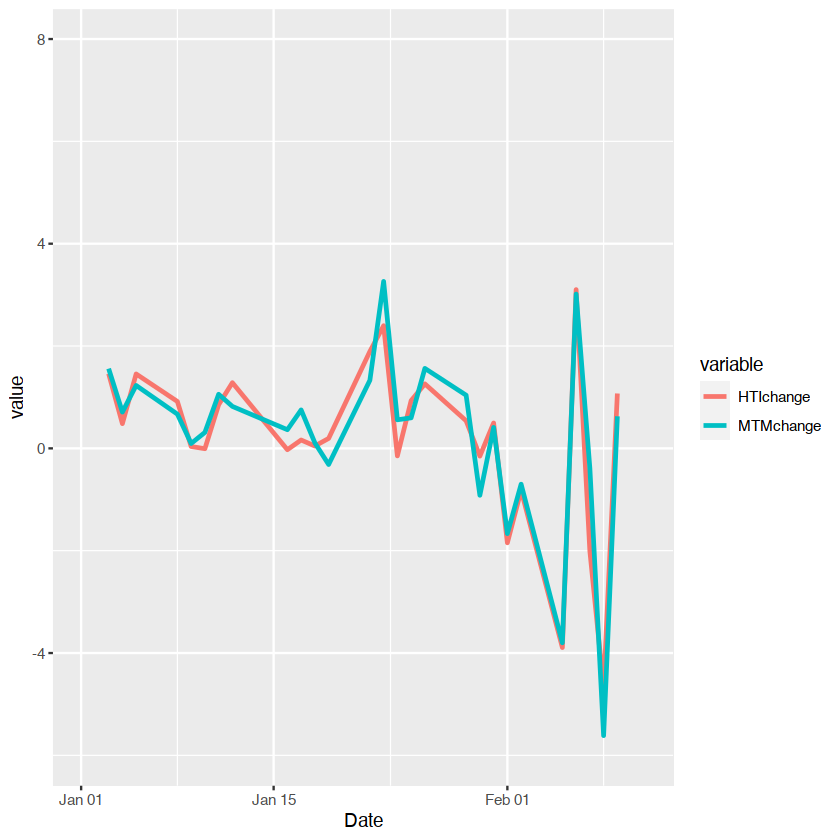

```r
data.frame(Date=stocks_data$Date,
         HTIchange= transmute(stocks_data, HTIchange=((HTI-lag(HTI))/lag(HTI))*100),
        MTMchange = transmute(stocks_data, MTMchange=((MTM-lag(MTM))/lag(MTM))*100)) %>%
reshape2::melt(id.vars="Date") %>%
ggplot(aes(x=Date, y=value, group=variable, color=variable)) + geom_line(size=1) +
 scale_x_date(limit=c(as.Date("2018-01-01"),as.Date("2018-02-11")))
```

## The above Graph shows HTI change and MTM change from January 2018 to February 2018

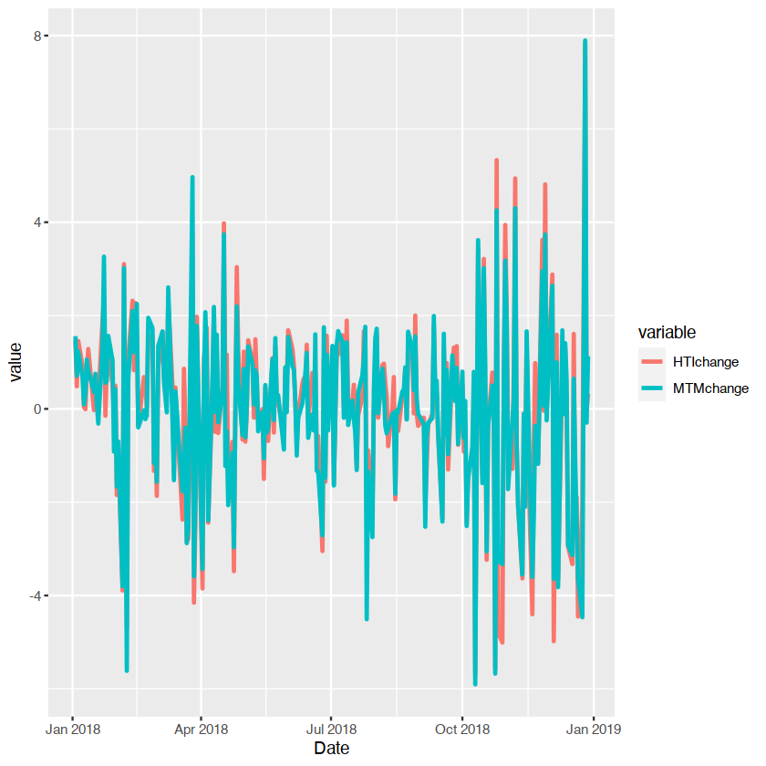

```r
data.frame(Date=stocks_data$Date,
         HTIchange= transmute(stocks_data, HTIchange=((HTI-lag(HTI))/lag(HTI))*100),
        MTMchange = transmute(stocks_data, MTMchange=((MTM-lag(MTM))/lag(MTM))*100)) %>%
reshape2::melt(id.vars="Date") %>%
ggplot(aes(x=Date, y=value, group=variable, color=variable)) + geom_line(size=1)
```

## The above Graph shows HTI change and MTM change from January 2018 to December 2018

```r
head(jpy_close)
```

A data.frame: 6 × 2

|  | Date <date> | JPY_Close <dbl> |
| --- | --- | --- |
| 1 | 2018-01-02 | 112.769997 |
| 2 | 2018-01-03 | 112.244003 |
| 3 | 2018-01-04 | 112.607002 |
| 4 | 2018-01-05 | 112.782997 |
| 5 | 2018-01-08 | 113.153999 |
| 6 | 2018-01-09 | 113.140999 |

```r
newstocks_data = merge(stocks_data, jpy_close, by = 'Date')
head(newstocks_data)
```

A data.frame: 6 × 25

|  | Date <date> | IBM_Close <dbl> | IBM_Adj.Close <dbl> | MSFT_Close <dbl> | MSFT_Adj.Close <dbl> | GOOG_Close <dbl> | GOOG_Adj.Close <dbl> | AMZN_Close <dbl> | AMZN_Adj.Close <dbl> | AAPL_Close <dbl> | ⋯ | TSLA_Close <dbl> | TSLA_Adj.Close <dbl> | ORCL_Close <dbl> | ORCL_Adj.Close <dbl> | SAP_Close <dbl> | SAP_Adj.Close <dbl> | Remaining_Cash <dbl> | MTM <dbl> | HTI <dbl> | JPY_Close <dbl> |
| --- | --- | --- | --- | --- | --- | --- | --- | --- | --- | --- | --- | --- | --- | --- | --- | --- | --- | --- | --- | --- | --- |
| 1 | 2018-01-02 | 154.250000 | 135.743759 | 85.949997 | 82.599319 | 1065.00000 | 1065.00000 | 1189.01001 | 1189.01001 | 43.064999 | ⋯ | 64.106003 | 64.106003 | 46.630001 | 44.522018 | 112.389999 | 107.653435 | 1294.78752 | 5000000.00 | 314.289101 | 112.769997 |
| 2 | 2018-01-03 | 158.490005 | 139.475113 | 86.349998 | 82.983727 | 1082.47998 | 1082.47998 | 1204.19995 | 1204.19995 | 43.057499 | ⋯ | 63.450001 | 63.450001 | 47.709999 | 45.553192 | 113.309998 | 108.534660 | 1294.78752 | 5077927.50 | 318.876743 | 112.244003 |
| 3 | 2018-01-04 | 161.699997 | 142.299957 | 87.110001 | 83.714119 | 1086.40002 | 1086.40002 | 1209.58997 | 1209.58997 | 43.257500 | ⋯ | 62.924000 | 62.924000 | 48.180000 | 46.001949 | 115.050003 | 110.201332 | 1294.78752 | 5113912.49 | 320.417150 | 112.607002 |
| 4 | 2018-01-05 | 162.490005 | 142.995193 | 88.190002 | 84.752014 | 1102.22998 | 1102.22998 | 1229.14001 | 1229.14001 | 43.750000 | ⋯ | 63.316002 | 63.316002 | 48.470001 | 46.278843 | 116.330002 | 111.427383 | 1294.78752 | 5176778.40 | 325.075602 | 112.782997 |
| 5 | 2018-01-08 | 163.470001 | 143.857620 | 88.279999 | 84.838486 | 1106.93994 | 1106.93994 | 1246.87000 | 1246.87000 | 43.587502 | ⋯ | 67.281998 | 67.281998 | 48.980000 | 46.765781 | 114.800003 | 109.961861 | 1294.78752 | 5211388.74 | 328.053944 | 113.153999 |
| 6 | 2018-01-09 | 163.830002 | 144.174408 | 88.220001 | 84.780838 | 1106.26001 | 1106.26001 | 1252.69995 | 1252.69995 | 43.582500 | ⋯ | 66.737999 | 66.737999 | 49.060001 | 47.024582 | 114.160004 | 109.348839 | 1261.97909 | 5216324.31 | 328.173046 | 113.140999 |

## We added a new columns which changes the MTM from USD to JPY according to the coversion rate for that particular date.

```r
newstocks_data$MTM_JPY = newstocks_data$MTM * newstocks_data$JPY_Close
head(newstocks_data)
```

A data.frame: 6 × 26

|  | Date <date> | IBM_Close <dbl> | IBM_Adj.Close <dbl> | MSFT_Close <dbl> | MSFT_Adj.Close <dbl> | GOOG_Close <dbl> | GOOG_Adj.Close <dbl> | AMZN_Close <dbl> | AMZN_Adj.Close <dbl> | AAPL_Close <dbl> | ⋯ | TSLA_Adj.Close <dbl> | ORCL_Close <dbl> | ORCL_Adj.Close <dbl> | SAP_Close <dbl> | SAP_Adj.Close <dbl> | Remaining_Cash <dbl> | MTM <dbl> | HTI <dbl> | JPY_Close <dbl> | MTM_JPY <dbl> |
| --- | --- | --- | --- | --- | --- | --- | --- | --- | --- | --- | --- | --- | --- | --- | --- | --- | --- | --- | --- | --- | --- |
| 1 | 2018-01-02 | 154.250000 | 135.743759 | 85.949997 | 82.599319 | 1065.00000 | 1065.00000 | 1189.01001 | 1189.01001 | 43.064999 | ⋯ | 64.106003 | 46.630001 | 44.522018 | 112.389999 | 107.653435 | 1294.78752 | 5000000.00 | 314.289101 | 112.769997 | 563849985 |
| 2 | 2018-01-03 | 158.490005 | 139.475113 | 86.349998 | 82.983727 | 1082.47998 | 1082.47998 | 1204.19995 | 1204.19995 | 43.057499 | ⋯ | 63.450001 | 47.709999 | 45.553192 | 113.309998 | 108.534660 | 1294.78752 | 5077927.50 | 318.876743 | 112.244003 | 569966909 |
| 3 | 2018-01-04 | 161.699997 | 142.299957 | 87.110001 | 83.714119 | 1086.40002 | 1086.40002 | 1209.58997 | 1209.58997 | 43.257500 | ⋯ | 62.924000 | 48.180000 | 46.001949 | 115.050003 | 110.201332 | 1294.78752 | 5113912.49 | 320.417150 | 112.607002 | 575862354 |
| 4 | 2018-01-05 | 162.490005 | 142.995193 | 88.190002 | 84.752014 | 1102.22998 | 1102.22998 | 1229.14001 | 1229.14001 | 43.750000 | ⋯ | 63.316002 | 48.470001 | 46.278843 | 116.330002 | 111.427383 | 1294.78752 | 5176778.40 | 325.075602 | 112.782997 | 583852583 |
| 5 | 2018-01-08 | 163.470001 | 143.857620 | 88.279999 | 84.838486 | 1106.93994 | 1106.93994 | 1246.87000 | 1246.87000 | 43.587502 | ⋯ | 67.281998 | 48.980000 | 46.765781 | 114.800003 | 109.961861 | 1294.78752 | 5211388.74 | 328.053944 | 113.153999 | 589689476 |
| 6 | 2018-01-09 | 163.830002 | 144.174408 | 88.220001 | 84.780838 | 1106.26001 | 1106.26001 | 1252.69995 | 1252.69995 | 43.582500 | ⋯ | 66.737999 | 49.060001 | 47.024582 | 114.160004 | 109.348839 | 1261.97909 | 5216324.31 | 328.173046 | 113.140999 | 590180144 |

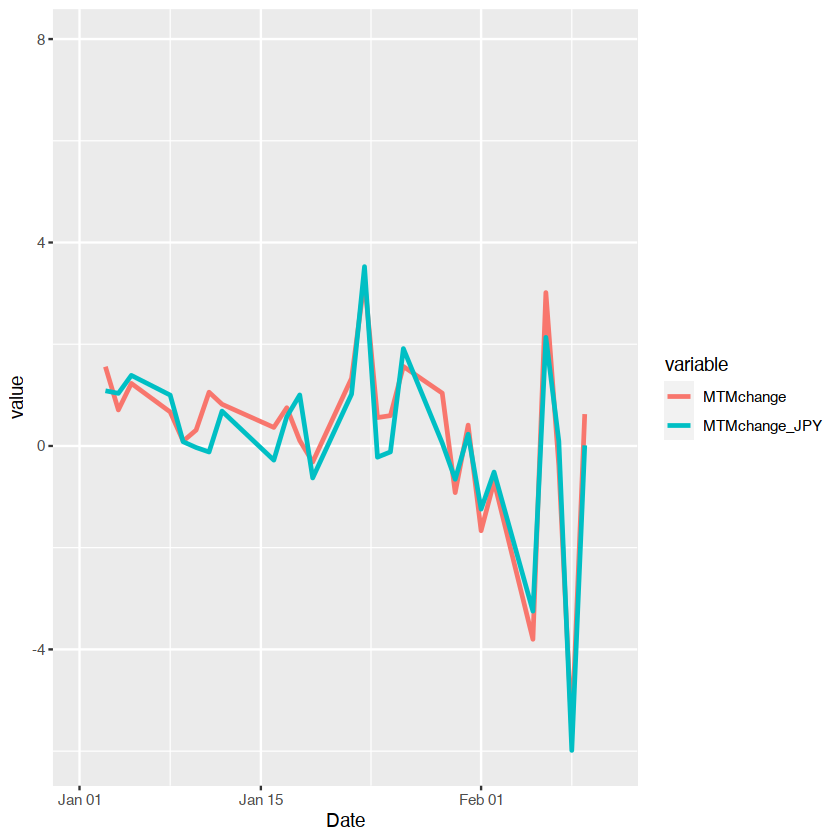

```r
data.frame(Date=newstocks_data$Date,
#          HTIchange= transmute(stocks_data, HTIchange=((HTI-lag(HTI))/lag(HTI))*100),
        MTMchange = transmute(newstocks_data, MTMchange=((MTM-lag(MTM))/lag(MTM))*100),
        MTMchange_JPY = transmute(newstocks_data, MTMchange_JPY=((MTM_JPY-lag(MTM_JPY))/lag(MTM_JPY))*100))%>%
reshape2::melt(id.vars="Date") %>%
ggplot(aes(x=Date, y=value, group=variable, color=variable)) + geom_line(size=1) +
 scale_x_date(limit=c(as.Date("2018-01-01"),as.Date("2018-02-11")))
```

## The above graph is for the comparison for USD and JPY MTM change from January to February

## 9. Trying Differnet intervals

#### MTM for different intervals / Strategy-1

##### Rebalancing every 2 days

```r
stocks_split_2 = stocks_data[seq(1,nrow(stocks_data),2),]


options(digits=9)
total_cash <- 5000000
remaining_cash <- total_cash
split <- total_cash/5
MTM <- 0
begin_date <- mdy('01/02/2018')
start_date <- begin_date
end_date <-  mdy('12/28/2018')
all_stocks <- c('IBM_Adj.Close','MSFT_Adj.Close','GOOG_Adj.Close','AAPL_Adj.Close','AMZN_Adj.Close','FB_Adj.Close','NFLX_Adj.Close','TSLA_Adj.Close','ORCL_Adj.Close','SAP_Adj.Close')
initial_stocks <- c('IBM_Close','MSFT_Close','GOOG_Close','AMZN_Close','FB_Close')
shares_count <- list()

# Main logic
while(start_date <= end_date){

    # executes the first day
    if(start_date == '2018-01-02'){
          for(i in initial_stocks) {
        a <- stocks_data[stocks_data$Date== start_date, initial_stocks]
        b<- floor(split/a[i])
        shares_count[i] <-  b[[i]]
        remaining_cash <- remaining_cash - b*a[i]
        MTM <- MTM + b*a[i]
        }
        colnames(remaining_cash) <- 'Remaining_Cash'
        stocks_data[stocks_data$Date == start_date,'Remaining_Cash'] <- remaining_cash
        colnames(MTM) <- 'MTM'
        MTM <- MTM + remaining_cash
        stocks_data[stocks_data$Date == start_date,'MTM'] <- MTM

}


    # This condition executes for every 5th day
    else if(start_date %in% stocks_split_2$Date) {
        MTM <- 0
        for(i in initial_stocks) {
        a <- stocks_data[stocks_data$Date== start_date, initial_stocks]
        MTM <- MTM + shares_count[[i]]*a[i]
        }
        total_cash <- MTM + remaining_cash
        remaining_cash <- total_cash
        split <- total_cash / 5
        colnames(total_cash) <- 'Total_Cash'
        colnames(MTM) <- 'MTM'
        calculated_stocks <- list()
        for(i in all_stocks){

            x <- stocks_data[stocks_data$Date== start_date, all_stocks]
            y <- stocks_data[stocks_data$Date== begin_date, all_stocks]
            percent_change <- 100 * ((x[i] - y[i])/ y[i])
            col <- paste0(i, "_PC")
            calculated_stocks[col] <- percent_change

        }
        calculated_stocks <- calculated_stocks[order(unlist(calculated_stocks))]
        calculated_stocks <- head(calculated_stocks,5)

        # update initial stocks
        initial_col_list <- names(calculated_stocks)
        initial_col_list <- sub('_.*','',initial_col_list)
        initial_col_list <- paste0(initial_col_list,'_Close')
        initial_stocks <- initial_col_list
        shares_count <- list()
        b <- list()
        MTM <- 0
        for(i in initial_stocks) {
        a <- stocks_data[stocks_data$Date== start_date, initial_stocks]
        b<- floor(split[,1]/a[i])
        shares_count[i] <-  b[[i]]
        remaining_cash <- remaining_cash - b*a[i]
        MTM <- MTM + b*a[i]
        }
        MTM <- MTM + remaining_cash
        stocks_data[stocks_data$Date == start_date,'MTM'] <- MTM
        stocks_data[stocks_data$Date == start_date,'Remaining_Cash'] <- remaining_cash


    }

    # This logic executes every day except the 5th day and returns MTM
    else {
        MTM <- 0
        for(i in initial_stocks) {
        a <- stocks_data[stocks_data$Date== start_date, initial_stocks]
        MTM <- MTM + shares_count[[i]]*a[i]
        }
        colnames(MTM) <- 'MTM'
        stocks_data[stocks_data$Date == start_date,'Remaining_Cash'] <- remaining_cash
        stocks_data[stocks_data$Date == start_date,'MTM'] <- MTM

    }
start_date <- start_date+1
}
# tail(stocks_data,10)
sr1_2 <- c('stocks_split_2',MTM = tail(stocks_data$MTM,1))
sr1_2
tail(stocks_data)
```

**1**

'stocks_split_2'

**MTM**

'5381844.33602'

A data.frame: 6 × 24

|  | Date <date> | IBM_Close <dbl> | IBM_Adj.Close <dbl> | MSFT_Close <dbl> | MSFT_Adj.Close <dbl> | GOOG_Close <dbl> | GOOG_Adj.Close <dbl> | AMZN_Close <dbl> | AMZN_Adj.Close <dbl> | AAPL_Close <dbl> | ⋯ | NFLX_Adj.Close <dbl> | TSLA_Close <dbl> | TSLA_Adj.Close <dbl> | ORCL_Close <dbl> | ORCL_Adj.Close <dbl> | SAP_Close <dbl> | SAP_Adj.Close <dbl> | Remaining_Cash <dbl> | MTM <dbl> | HTI <dbl> |
| --- | --- | --- | --- | --- | --- | --- | --- | --- | --- | --- | --- | --- | --- | --- | --- | --- | --- | --- | --- | --- | --- |
| 245 | 2018-12-20 | 113.019997 | 103.959160 | 101.510002 | 99.241501 | 1009.409973 | 1009.409973 | 1460.82996 | 1460.82996 | 39.207500 | ⋯ | 260.579987 | 63.076000 | 63.076000 | 46.240002 | 44.859539 | 100.099998 | 97.349060 | 1011.849494 | 5363875.47 | 332.737341 |
| 246 | 2018-12-21 | 110.940002 | 102.045921 | 98.230003 | 96.034790 | 979.539978 | 979.539978 | 1377.44995 | 1377.44995 | 37.682499 | ⋯ | 246.389999 | 63.953999 | 63.953999 | 44.000000 | 42.686417 | 96.139999 | 93.497887 | 1011.849494 | 5159289.17 | 317.927643 |
| 247 | 2018-12-24 | 107.570000 | 98.946083 | 94.129997 | 92.026421 | 976.219971 | 976.219971 | 1343.95996 | 1343.95996 | 36.707500 | ⋯ | 233.880005 | 59.077999 | 59.077999 | 42.689999 | 41.415524 | 95.000000 | 92.389214 | 642.534148 | 5078739.68 | 311.329543 |
| 248 | 2018-12-26 | 111.389999 | 102.459846 | 100.559998 | 98.312729 | 1039.459961 | 1039.459961 | 1470.90002 | 1470.90002 | 39.292500 | ⋯ | 253.669998 | 65.218002 | 65.218002 | 44.590000 | 43.258801 | 98.379997 | 95.676323 | 642.534148 | 5370456.03 | 335.764047 |
| 249 | 2018-12-27 | 113.779999 | 104.658234 | 101.180000 | 98.918884 | 1043.880005 | 1043.880005 | 1461.64001 | 1461.64001 | 39.037498 | ⋯ | 255.570007 | 63.226002 | 63.226002 | 44.970001 | 43.627453 | 98.989998 | 96.269554 | 191.718944 | 5400511.43 | 335.679353 |
| 250 | 2018-12-28 | 113.029999 | 103.968369 | 100.389999 | 98.146530 | 1037.079956 | 1037.079956 | 1478.02002 | 1478.02002 | 39.057499 | ⋯ | 256.079987 | 66.774002 | 66.774002 | 44.820000 | 43.481926 | 99.199997 | 96.473785 | 191.718944 | 5381844.34 | 336.765146 |

#### MTM for different intervals / Strategy-1

##### Rebalancing every 20 days

```r
stocks_split_20 = stocks_data[seq(1,nrow(stocks_data),20),]


options(digits=9)
total_cash <- 5000000
remaining_cash <- total_cash
split <- total_cash/5
MTM <- 0
begin_date <- mdy('01/02/2018')
start_date <- begin_date
end_date <-  mdy('12/28/2018')
all_stocks <- c('IBM_Adj.Close','MSFT_Adj.Close','GOOG_Adj.Close','AAPL_Adj.Close','AMZN_Adj.Close','FB_Adj.Close','NFLX_Adj.Close','TSLA_Adj.Close','ORCL_Adj.Close','SAP_Adj.Close')
initial_stocks <- c('IBM_Close','MSFT_Close','GOOG_Close','AMZN_Close','FB_Close')
shares_count <- list()

# Main logic
while(start_date <= end_date){

    # executes the first day
    if(start_date == '2018-01-02'){
          for(i in initial_stocks) {
        a <- stocks_data[stocks_data$Date== start_date, initial_stocks]
        b<- floor(split/a[i])
        shares_count[i] <-  b[[i]]
        remaining_cash <- remaining_cash - b*a[i]
        MTM <- MTM + b*a[i]
        }
        colnames(remaining_cash) <- 'Remaining_Cash'
        stocks_data[stocks_data$Date == start_date,'Remaining_Cash'] <- remaining_cash
        colnames(MTM) <- 'MTM'
        MTM <- MTM + remaining_cash
        stocks_data[stocks_data$Date == start_date,'MTM'] <- MTM

}


    # This condition executes for every 5th day
    else if(start_date %in% stocks_split_20$Date) {
        MTM <- 0
        for(i in initial_stocks) {
        a <- stocks_data[stocks_data$Date== start_date, initial_stocks]
        MTM <- MTM + shares_count[[i]]*a[i]
        }
        total_cash <- MTM + remaining_cash
        remaining_cash <- total_cash
        split <- total_cash / 5
        colnames(total_cash) <- 'Total_Cash'
        colnames(MTM) <- 'MTM'
        calculated_stocks <- list()
        for(i in all_stocks){

            x <- stocks_data[stocks_data$Date== start_date, all_stocks]
            y <- stocks_data[stocks_data$Date== begin_date, all_stocks]
            percent_change <- 100 * ((x[i] - y[i])/ y[i])
            col <- paste0(i, "_PC")
            calculated_stocks[col] <- percent_change

        }
        calculated_stocks <- calculated_stocks[order(unlist(calculated_stocks))]
        calculated_stocks <- head(calculated_stocks,5)

        # update initial stocks
        initial_col_list <- names(calculated_stocks)
        initial_col_list <- sub('_.*','',initial_col_list)
        initial_col_list <- paste0(initial_col_list,'_Close')
        initial_stocks <- initial_col_list
        shares_count <- list()
        b <- list()
        MTM <- 0
        for(i in initial_stocks) {
        a <- stocks_data[stocks_data$Date== start_date, initial_stocks]
        b<- floor(split[,1]/a[i])
        shares_count[i] <-  b[[i]]
        remaining_cash <- remaining_cash - b*a[i]
        MTM <- MTM + b*a[i]
        }
        MTM <- MTM + remaining_cash
        stocks_data[stocks_data$Date == start_date,'MTM'] <- MTM
        stocks_data[stocks_data$Date == start_date,'Remaining_Cash'] <- remaining_cash


    }

    # This logic executes every day except the 5th day and returns MTM
    else {
        MTM <- 0
        for(i in initial_stocks) {
        a <- stocks_data[stocks_data$Date== start_date, initial_stocks]
        MTM <- MTM + shares_count[[i]]*a[i]
        }
        colnames(MTM) <- 'MTM'
        stocks_data[stocks_data$Date == start_date,'Remaining_Cash'] <- remaining_cash
        stocks_data[stocks_data$Date == start_date,'MTM'] <- MTM

    }
start_date <- start_date+1
}
# tail(stocks_data,10)
sr1_20 <- c('stocks_split_20',MTM = tail(stocks_data$MTM,1))
sr1_20
tail(stocks_data)
```

**1**

'stocks_split_20'

**MTM**

'5396704.411344'

A data.frame: 6 × 24

|  | Date <date> | IBM_Close <dbl> | IBM_Adj.Close <dbl> | MSFT_Close <dbl> | MSFT_Adj.Close <dbl> | GOOG_Close <dbl> | GOOG_Adj.Close <dbl> | AMZN_Close <dbl> | AMZN_Adj.Close <dbl> | AAPL_Close <dbl> | ⋯ | NFLX_Adj.Close <dbl> | TSLA_Close <dbl> | TSLA_Adj.Close <dbl> | ORCL_Close <dbl> | ORCL_Adj.Close <dbl> | SAP_Close <dbl> | SAP_Adj.Close <dbl> | Remaining_Cash <dbl> | MTM <dbl> | HTI <dbl> |
| --- | --- | --- | --- | --- | --- | --- | --- | --- | --- | --- | --- | --- | --- | --- | --- | --- | --- | --- | --- | --- | --- |
| 245 | 2018-12-20 | 113.019997 | 103.959160 | 101.510002 | 99.241501 | 1009.409973 | 1009.409973 | 1460.82996 | 1460.82996 | 39.207500 | ⋯ | 260.579987 | 63.076000 | 63.076000 | 46.240002 | 44.859539 | 100.099998 | 97.349060 | 761.805139 | 5382394.21 | 332.737341 |
| 246 | 2018-12-21 | 110.940002 | 102.045921 | 98.230003 | 96.034790 | 979.539978 | 979.539978 | 1377.44995 | 1377.44995 | 37.682499 | ⋯ | 246.389999 | 63.953999 | 63.953999 | 44.000000 | 42.686417 | 96.139999 | 93.497887 | 761.805139 | 5178709.27 | 317.927643 |
| 247 | 2018-12-24 | 107.570000 | 98.946083 | 94.129997 | 92.026421 | 976.219971 | 976.219971 | 1343.95996 | 1343.95996 | 36.707500 | ⋯ | 233.880005 | 59.077999 | 59.077999 | 42.689999 | 41.415524 | 95.000000 | 92.389214 | 761.805139 | 5097195.58 | 311.329543 |
| 248 | 2018-12-26 | 111.389999 | 102.459846 | 100.559998 | 98.312729 | 1039.459961 | 1039.459961 | 1470.90002 | 1470.90002 | 39.292500 | ⋯ | 253.669998 | 65.218002 | 65.218002 | 44.590000 | 43.258801 | 98.379997 | 95.676323 | 761.805139 | 5388778.64 | 335.764047 |
| 249 | 2018-12-27 | 113.779999 | 104.658234 | 101.180000 | 98.918884 | 1043.880005 | 1043.880005 | 1461.64001 | 1461.64001 | 39.037498 | ⋯ | 255.570007 | 63.226002 | 63.226002 | 44.970001 | 43.627453 | 98.989998 | 96.269554 | 761.805139 | 5418543.20 | 335.679353 |
| 250 | 2018-12-28 | 113.029999 | 103.968369 | 100.389999 | 98.146530 | 1037.079956 | 1037.079956 | 1478.02002 | 1478.02002 | 39.057499 | ⋯ | 256.079987 | 66.774002 | 66.774002 | 44.820000 | 43.481926 | 99.199997 | 96.473785 | 761.805139 | 5396704.41 | 336.765146 |

## Here we are getting more profit if we rebalance every 20 days, when buying low

#### MTM for different intervals / Strategy-2

##### Rebalancing every 11 days

```r
stocks_split_11 = stocks_data[seq(1,nrow(stocks_data),11),]


options(digits=9)
total_cash <- 5000000
remaining_cash <- total_cash
split <- total_cash/5
MTM <- 0
begin_date <- mdy('01/02/2018')
start_date <- begin_date
end_date <-  mdy('12/28/2018')
all_stocks <- c('IBM_Adj.Close','MSFT_Adj.Close','GOOG_Adj.Close','AAPL_Adj.Close','AMZN_Adj.Close','FB_Adj.Close','NFLX_Adj.Close','TSLA_Adj.Close','ORCL_Adj.Close','SAP_Adj.Close')
initial_stocks <- c('IBM_Close','MSFT_Close','GOOG_Close','AMZN_Close','FB_Close')
shares_count <- list()

# Main logic
while(start_date <= end_date){

    # executes the first day
    if(start_date == '2018-01-02'){
          for(i in initial_stocks) {
        a <- stocks_data[stocks_data$Date== start_date, initial_stocks]
        b<- floor(split/a[i])
        shares_count[i] <-  b[[i]]
        remaining_cash <- remaining_cash - b*a[i]
        MTM <- MTM + b*a[i]
        }
        colnames(remaining_cash) <- 'Remaining_Cash'
        stocks_data[stocks_data$Date == start_date,'Remaining_Cash'] <- remaining_cash
        colnames(MTM) <- 'MTM'
        MTM <- MTM + remaining_cash
        stocks_data[stocks_data$Date == start_date,'MTM'] <- MTM

}


    # This condition executes for every 5th day
    else if(start_date %in% stocks_split_11$Date) {
        MTM <- 0
        for(i in initial_stocks) {
        a <- stocks_data[stocks_data$Date== start_date, initial_stocks]
        MTM <- MTM + shares_count[[i]]*a[i]
        }
        total_cash <- MTM + remaining_cash
        remaining_cash <- total_cash
        split <- total_cash / 5
        colnames(total_cash) <- 'Total_Cash'
        colnames(MTM) <- 'MTM'
        calculated_stocks <- list()
        for(i in all_stocks){

            x <- stocks_data[stocks_data$Date== start_date, all_stocks]
            y <- stocks_data[stocks_data$Date== begin_date, all_stocks]
            percent_change <- 100 * ((x[i] - y[i])/ y[i])
            col <- paste0(i, "_PC")
            calculated_stocks[col] <- percent_change

        }
        calculated_stocks <- calculated_stocks[order(unlist(calculated_stocks))]
        calculated_stocks <- tail(calculated_stocks,5)

        # update initial stocks
        initial_col_list <- names(calculated_stocks)
        initial_col_list <- sub('_.*','',initial_col_list)
        initial_col_list <- paste0(initial_col_list,'_Close')
        initial_stocks <- initial_col_list
        shares_count <- list()
        b <- list()
        MTM <- 0
        for(i in initial_stocks) {
        a <- stocks_data[stocks_data$Date== start_date, initial_stocks]
        b<- floor(split[,1]/a[i])
        shares_count[i] <-  b[[i]]
        remaining_cash <- remaining_cash - b*a[i]
        MTM <- MTM + b*a[i]
        }
        MTM <- MTM + remaining_cash
        stocks_data[stocks_data$Date == start_date,'MTM'] <- MTM
        stocks_data[stocks_data$Date == start_date,'Remaining_Cash'] <- remaining_cash


    }

    # This logic executes every day except the 5th day and returns MTM
    else {
        MTM <- 0
        for(i in initial_stocks) {
        a <- stocks_data[stocks_data$Date== start_date, initial_stocks]
        MTM <- MTM + shares_count[[i]]*a[i]
        }
        colnames(MTM) <- 'MTM'
        stocks_data[stocks_data$Date == start_date,'Remaining_Cash'] <- remaining_cash
        stocks_data[stocks_data$Date == start_date,'MTM'] <- MTM

    }
start_date <- start_date+1
}
# tail(stocks_data,10)
sr2_11 <- c('stocks_split_11',MTM = tail(stocks_data$MTM,1))
sr2_11
tail(stocks_data)
```

**1**

'stocks_split_11'

**MTM**

'5107777.868096'

A data.frame: 6 × 24

|  | Date <date> | IBM_Close <dbl> | IBM_Adj.Close <dbl> | MSFT_Close <dbl> | MSFT_Adj.Close <dbl> | GOOG_Close <dbl> | GOOG_Adj.Close <dbl> | AMZN_Close <dbl> | AMZN_Adj.Close <dbl> | AAPL_Close <dbl> | ⋯ | NFLX_Adj.Close <dbl> | TSLA_Close <dbl> | TSLA_Adj.Close <dbl> | ORCL_Close <dbl> | ORCL_Adj.Close <dbl> | SAP_Close <dbl> | SAP_Adj.Close <dbl> | Remaining_Cash <dbl> | MTM <dbl> | HTI <dbl> |
| --- | --- | --- | --- | --- | --- | --- | --- | --- | --- | --- | --- | --- | --- | --- | --- | --- | --- | --- | --- | --- | --- |
| 245 | 2018-12-20 | 113.019997 | 103.959160 | 101.510002 | 99.241501 | 1009.409973 | 1009.409973 | 1460.82996 | 1460.82996 | 39.207500 | ⋯ | 260.579987 | 63.076000 | 63.076000 | 46.240002 | 44.859539 | 100.099998 | 97.349060 | 1106.6293 | 5099762.09 | 332.737341 |
| 246 | 2018-12-21 | 110.940002 | 102.045921 | 98.230003 | 96.034790 | 979.539978 | 979.539978 | 1377.44995 | 1377.44995 | 37.682499 | ⋯ | 246.389999 | 63.953999 | 63.953999 | 44.000000 | 42.686417 | 96.139999 | 93.497887 | 1106.6293 | 4916366.75 | 317.927643 |
| 247 | 2018-12-24 | 107.570000 | 98.946083 | 94.129997 | 92.026421 | 976.219971 | 976.219971 | 1343.95996 | 1343.95996 | 36.707500 | ⋯ | 233.880005 | 59.077999 | 59.077999 | 42.689999 | 41.415524 | 95.000000 | 92.389214 | 1106.6293 | 4696352.83 | 311.329543 |
| 248 | 2018-12-26 | 111.389999 | 102.459846 | 100.559998 | 98.312729 | 1039.459961 | 1039.459961 | 1470.90002 | 1470.90002 | 39.292500 | ⋯ | 253.669998 | 65.218002 | 65.218002 | 44.590000 | 43.258801 | 98.379997 | 95.676323 | 1106.6293 | 5065542.59 | 335.764047 |
| 249 | 2018-12-27 | 113.779999 | 104.658234 | 101.180000 | 98.918884 | 1043.880005 | 1043.880005 | 1461.64001 | 1461.64001 | 39.037498 | ⋯ | 255.570007 | 63.226002 | 63.226002 | 44.970001 | 43.627453 | 98.989998 | 96.269554 | 1106.6293 | 5050472.85 | 335.679353 |
| 250 | 2018-12-28 | 113.029999 | 103.968369 | 100.389999 | 98.146530 | 1037.079956 | 1037.079956 | 1478.02002 | 1478.02002 | 39.057499 | ⋯ | 256.079987 | 66.774002 | 66.774002 | 44.820000 | 43.481926 | 99.199997 | 96.473785 | 1106.6293 | 5107777.87 | 336.765146 |

#### MTM for different intervals / Strategy-2

##### Rebalancing every 7 days

```r
stocks_split_7 = stocks_data[seq(1,nrow(stocks_data),7),]


options(digits=9)
total_cash <- 5000000
remaining_cash <- total_cash
split <- total_cash/5
MTM <- 0
begin_date <- mdy('01/02/2018')
start_date <- begin_date
end_date <-  mdy('12/28/2018')
all_stocks <- c('IBM_Adj.Close','MSFT_Adj.Close','GOOG_Adj.Close','AAPL_Adj.Close','AMZN_Adj.Close','FB_Adj.Close','NFLX_Adj.Close','TSLA_Adj.Close','ORCL_Adj.Close','SAP_Adj.Close')
initial_stocks <- c('IBM_Close','MSFT_Close','GOOG_Close','AMZN_Close','FB_Close')
shares_count <- list()

# Main logic
while(start_date <= end_date){

    # executes the first day
    if(start_date == '2018-01-02'){
          for(i in initial_stocks) {
        a <- stocks_data[stocks_data$Date== start_date, initial_stocks]
        b<- floor(split/a[i])
        shares_count[i] <-  b[[i]]
        remaining_cash <- remaining_cash - b*a[i]
        MTM <- MTM + b*a[i]
        }
        colnames(remaining_cash) <- 'Remaining_Cash'
        stocks_data[stocks_data$Date == start_date,'Remaining_Cash'] <- remaining_cash
        colnames(MTM) <- 'MTM'
        MTM <- MTM + remaining_cash
        stocks_data[stocks_data$Date == start_date,'MTM'] <- MTM

}


    # This condition executes for every 5th day
    else if(start_date %in% stocks_split_7$Date) {
        MTM <- 0
        for(i in initial_stocks) {
        a <- stocks_data[stocks_data$Date== start_date, initial_stocks]
        MTM <- MTM + shares_count[[i]]*a[i]
        }
        total_cash <- MTM + remaining_cash
        remaining_cash <- total_cash
        split <- total_cash / 5
        colnames(total_cash) <- 'Total_Cash'
        colnames(MTM) <- 'MTM'
        calculated_stocks <- list()
        for(i in all_stocks){

            x <- stocks_data[stocks_data$Date== start_date, all_stocks]
            y <- stocks_data[stocks_data$Date== begin_date, all_stocks]
            percent_change <- 100 * ((x[i] - y[i])/ y[i])
            col <- paste0(i, "_PC")
            calculated_stocks[col] <- percent_change

        }
        calculated_stocks <- calculated_stocks[order(unlist(calculated_stocks))]
        calculated_stocks <- tail(calculated_stocks,5)

        # update initial stocks
        initial_col_list <- names(calculated_stocks)
        initial_col_list <- sub('_.*','',initial_col_list)
        initial_col_list <- paste0(initial_col_list,'_Close')
        initial_stocks <- initial_col_list
        shares_count <- list()
        b <- list()
        MTM <- 0
        for(i in initial_stocks) {
        a <- stocks_data[stocks_data$Date== start_date, initial_stocks]
        b<- floor(split[,1]/a[i])
        shares_count[i] <-  b[[i]]
        remaining_cash <- remaining_cash - b*a[i]
        MTM <- MTM + b*a[i]
        }
        MTM <- MTM + remaining_cash
        stocks_data[stocks_data$Date == start_date,'MTM'] <- MTM
        stocks_data[stocks_data$Date == start_date,'Remaining_Cash'] <- remaining_cash


    }

    # This logic executes every day except the 5th day and returns MTM
    else {
        MTM <- 0
        for(i in initial_stocks) {
        a <- stocks_data[stocks_data$Date== start_date, initial_stocks]
        MTM <- MTM + shares_count[[i]]*a[i]
        }
        colnames(MTM) <- 'MTM'
        stocks_data[stocks_data$Date == start_date,'Remaining_Cash'] <- remaining_cash
        stocks_data[stocks_data$Date == start_date,'MTM'] <- MTM

    }
start_date <- start_date+1
}
# tail(stocks_data,10)
sr2_7<- c('stocks_split_7',MTM = tail(stocks_data$MTM,1))
sr2_7
tail(stocks_data)
```

**1**

'stocks_split_7'

**MTM**

'4791447.926183'

A data.frame: 6 × 24

|  | Date <date> | IBM_Close <dbl> | IBM_Adj.Close <dbl> | MSFT_Close <dbl> | MSFT_Adj.Close <dbl> | GOOG_Close <dbl> | GOOG_Adj.Close <dbl> | AMZN_Close <dbl> | AMZN_Adj.Close <dbl> | AAPL_Close <dbl> | ⋯ | NFLX_Adj.Close <dbl> | TSLA_Close <dbl> | TSLA_Adj.Close <dbl> | ORCL_Close <dbl> | ORCL_Adj.Close <dbl> | SAP_Close <dbl> | SAP_Adj.Close <dbl> | Remaining_Cash <dbl> | MTM <dbl> | HTI <dbl> |
| --- | --- | --- | --- | --- | --- | --- | --- | --- | --- | --- | --- | --- | --- | --- | --- | --- | --- | --- | --- | --- | --- |
| 245 | 2018-12-20 | 113.019997 | 103.959160 | 101.510002 | 99.241501 | 1009.409973 | 1009.409973 | 1460.82996 | 1460.82996 | 39.207500 | ⋯ | 260.579987 | 63.076000 | 63.076000 | 46.240002 | 44.859539 | 100.099998 | 97.349060 | 520.461717 | 4784300.24 | 332.737341 |
| 246 | 2018-12-21 | 110.940002 | 102.045921 | 98.230003 | 96.034790 | 979.539978 | 979.539978 | 1377.44995 | 1377.44995 | 37.682499 | ⋯ | 246.389999 | 63.953999 | 63.953999 | 44.000000 | 42.686417 | 96.139999 | 93.497887 | 942.698472 | 4610729.89 | 317.927643 |
| 247 | 2018-12-24 | 107.570000 | 98.946083 | 94.129997 | 92.026421 | 976.219971 | 976.219971 | 1343.95996 | 1343.95996 | 36.707500 | ⋯ | 233.880005 | 59.077999 | 59.077999 | 42.689999 | 41.415524 | 95.000000 | 92.389214 | 942.698472 | 4404327.37 | 311.329543 |
| 248 | 2018-12-26 | 111.389999 | 102.459846 | 100.559998 | 98.312729 | 1039.459961 | 1039.459961 | 1470.90002 | 1470.90002 | 39.292500 | ⋯ | 253.669998 | 65.218002 | 65.218002 | 44.590000 | 43.258801 | 98.379997 | 95.676323 | 942.698472 | 4752007.73 | 335.764047 |
| 249 | 2018-12-27 | 113.779999 | 104.658234 | 101.180000 | 98.918884 | 1043.880005 | 1043.880005 | 1461.64001 | 1461.64001 | 39.037498 | ⋯ | 255.570007 | 63.226002 | 63.226002 | 44.970001 | 43.627453 | 98.989998 | 96.269554 | 942.698472 | 4737985.60 | 335.679353 |
| 250 | 2018-12-28 | 113.029999 | 103.968369 | 100.389999 | 98.146530 | 1037.079956 | 1037.079956 | 1478.02002 | 1478.02002 | 39.057499 | ⋯ | 256.079987 | 66.774002 | 66.774002 | 44.820000 | 43.481926 | 99.199997 | 96.473785 | 942.698472 | 4791447.93 | 336.765146 |

## Here if we rebalance every 11 days we get a profit, when buying High

```r
result_strategy1 <- rbind(sr1_5,sr1_2,sr1_20)
result_strategy1
```

A matrix: 3 × 2 of type chr

|  |  | MTM |
| --- | --- | --- |
| sr1_5 | stocks_split_5 | 5323137.228935 |
| sr1_2 | stocks_split_2 | 5381844.33602 |
| sr1_20 | stocks_split_20 | 5396704.411344 |

## MTM cash according to rebalance days, when buying low

```r
result_strategy2 <- rbind(sr2_5,sr2_11,sr2_7)
result_strategy2
```

A matrix: 3 × 2 of type chr

|  |  | MTM |
| --- | --- | --- |
| sr2_5 | stocks_split_5 | 4761841.916281 |
| sr2_11 | stocks_split_11 | 5107777.868096 |
| sr2_7 | stocks_split_7 | 4791447.926183 |

## MTM cash according to rebalance days, when buying High

Dividends

```r
IBM1 <-ibm_data %>%
  mutate(Ratio.AdjClose = lag(Adj.Close, default = 0) / Adj.Close,
        Ratio.Close = lag(Close, default = 0) / Close) %>%
  mutate(ibm_data,Difference = Ratio.AdjClose-Ratio.Close) %>%
  mutate(ibm_data, Dividend = Difference*Close)
 IBM1$IBM_Absolute_Dividend = abs(IBM1$Dividend)
IBM1 <-  rename(IBM1, 'IBM_Date' = 'Date')
IBM1 <- select (IBM1, IBM_Date, IBM_Absolute_Dividend) %>%
filter (IBM_Absolute_Dividend > 0.01)

IBM1
```

A data.frame: 4 × 2

| IBM_Date <chr> | IBM_Absolute_Dividend <dbl> |
| --- | --- |
| 2018-02-08 | 1.50000622 |
| 2018-05-09 | 1.56998355 |
| 2018-08-09 | 1.57001381 |
| 2018-11-08 | 1.56999869 |

```r
amzn1 <-amzn_data %>%
  mutate(Ratio.AdjClose = lag(Adj.Close, default = 0) / Adj.Close,
        Ratio.Close = lag(Close, default = 0) / Close) %>%
  mutate(amzn_data,Difference = Ratio.AdjClose-Ratio.Close) %>%
  mutate(amzn_data, Dividend = Difference*Close)
 amzn1$Absolute_Dividend = abs(amzn1$Dividend)
select (amzn1, Date, Absolute_Dividend) %>%
filter (Absolute_Dividend > 0.01)
```

A data.frame: 0 × 2

| Date | Absolute_Dividend |
| --- | --- |
| <chr> | <dbl> |

```r
msft1 <-msft_data %>%
  mutate(Ratio.AdjClose = lag(Adj.Close, default = 0) / Adj.Close,
        Ratio.Close = lag(Close, default = 0) / Close) %>%
  mutate(msft_data,Difference = Ratio.AdjClose-Ratio.Close) %>%
  mutate(msft_data, Dividend = Difference*Close)
 msft1$MSFT_Absolute_Dividend = abs(msft1$Dividend)
msft1 <-  rename(msft1, 'MSFT_Date' = 'Date')
msft1 <- select (msft1, MSFT_Date, MSFT_Absolute_Dividend) %>%
filter (MSFT_Absolute_Dividend > 0.01)
msft1
```

A data.frame: 4 × 2

| MSFT_Date <chr> | MSFT_Absolute_Dividend <dbl> |
| --- | --- |
| 2018-02-14 | 0.420014632 |
| 2018-05-16 | 0.419976555 |
| 2018-08-15 | 0.419998784 |
| 2018-11-14 | 0.459999119 |

```r
goog1 <-goog_data %>%
  mutate(Ratio.AdjClose = lag(Adj.Close, default = 0) / Adj.Close,
        Ratio.Close = lag(Close, default = 0) / Close) %>%
  mutate(goog_data,Difference = Ratio.AdjClose-Ratio.Close) %>%
  mutate(goog_data, Dividend = Difference*Close)
 goog1$Absolute_Dividend = abs(goog1$Dividend)
select (goog1, Date, Absolute_Dividend) %>%
filter (Absolute_Dividend > 0.01)
```

A data.frame: 0 × 2

| Date | Absolute_Dividend |
| --- | --- |
| <chr> | <dbl> |

```r
aapl1 <-aapl_data %>%
  mutate(Ratio.AdjClose = lag(Adj.Close, default = 0) / Adj.Close,
        Ratio.Close = lag(Close, default = 0) / Close) %>%
  mutate(aapl_data,Difference = Ratio.AdjClose-Ratio.Close) %>%
  mutate(aapl_data, Dividend = Difference*Close)
 aapl1$AAPL_Absolute_Dividend = abs(aapl1$Dividend)

aapl1 <-  rename(aapl1, 'AAPL_Date' = 'Date')
aapl1 <- select (aapl1, AAPL_Date, AAPL_Absolute_Dividend) %>%
filter (AAPL_Absolute_Dividend > 0.01)
aapl1
```

A data.frame: 4 × 2

| AAPL_Date <chr> | AAPL_Absolute_Dividend <dbl> |
| --- | --- |
| 2018-02-09 | 0.157493725 |
| 2018-05-11 | 0.182501822 |
| 2018-08-10 | 0.182493795 |
| 2018-11-08 | 0.182498613 |

```r
fb1 <-fb_data %>%
  mutate(Ratio.AdjClose = lag(Adj.Close, default = 0) / Adj.Close,
        Ratio.Close = lag(Close, default = 0) / Close) %>%
  mutate(fb_data,Difference = Ratio.AdjClose-Ratio.Close) %>%
  mutate(fb_data, Dividend = Difference*Close)
 fb1$Absolute_Dividend = abs(fb1$Dividend)
select (fb1, Date, Absolute_Dividend) %>%
filter (Absolute_Dividend > 0.01)
```

A data.frame: 0 × 2

| Date | Absolute_Dividend |
| --- | --- |
| <chr> | <dbl> |

```r
nflx1 <-nflx_data %>%
  mutate(Ratio.AdjClose = lag(Adj.Close, default = 0) / Adj.Close,
        Ratio.Close = lag(Close, default = 0) / Close) %>%
  mutate(nflx_data,Difference = Ratio.AdjClose-Ratio.Close) %>%
  mutate(nflx_data, Dividend = Difference*Close)
 nflx1$Absolute_Dividend = abs(nflx1$Dividend)
select (nflx1, Date, Absolute_Dividend) %>%
filter (Absolute_Dividend > 0.01)
```

A data.frame: 0 × 2

| Date | Absolute_Dividend |
| --- | --- |
| <chr> | <dbl> |

```r
tsla1 <-tsla_data %>%
  mutate(Ratio.AdjClose = lag(Adj.Close, default = 0) / Adj.Close,
        Ratio.Close = lag(Close, default = 0) / Close) %>%
  mutate(tsla_data,Difference = Ratio.AdjClose-Ratio.Close) %>%
  mutate(tsla_data, Dividend = Difference*Close)
 tsla1$Absolute_Dividend = abs(tsla1$Dividend)
select (tsla1, Date, Absolute_Dividend) %>%
filter (Absolute_Dividend > 0.01)
```

A data.frame: 0 × 2

| Date | Absolute_Dividend |
| --- | --- |
| <chr> | <dbl> |

```r
orcl1 <-orcl_data %>%
  mutate(Ratio.AdjClose = lag(Adj.Close, default = 0) / Adj.Close,
        Ratio.Close = lag(Close, default = 0) / Close) %>%
  mutate(orcl_data,Difference = Ratio.AdjClose-Ratio.Close) %>%
  mutate(orcl_data, Dividend = Difference*Close)
 orcl1$ORCL_Absolute_Dividend = abs(orcl1$Dividend)

orcl1 <-  rename(orcl1, 'ORCL_Date' = 'Date')
orcl1 <- select (orcl1, ORCL_Date, ORCL_Absolute_Dividend) %>%
filter (ORCL_Absolute_Dividend > 0.01)
orcl1
```

A data.frame: 4 × 2

| ORCL_Date <chr> | ORCL_Absolute_Dividend <dbl> |
| --- | --- |
| 2018-01-09 | 0.190001981 |
| 2018-04-16 | 0.190002162 |
| 2018-07-16 | 0.190002924 |
| 2018-10-15 | 0.190010463 |

```r
sap1 <-sap_data %>%
  mutate(Ratio.AdjClose = lag(Adj.Close, default = 0) / Adj.Close,
        Ratio.Close = lag(Close, default = 0) / Close) %>%
  mutate(sap_data,Difference = Ratio.AdjClose-Ratio.Close) %>%
  mutate(sap_data, Dividend = Difference*Close)
 sap1$SAP_Absolute_Dividend = abs(sap1$Dividend)

sap1 <-  rename(sap1, 'SAP_Date' = 'Date')
sap1 <-  select (sap1, SAP_Date, SAP_Absolute_Dividend)%>%
filter (SAP_Absolute_Dividend > 0.01)
sap1
```

A data.frame: 1 × 2

| SAP_Date <chr> | SAP_Absolute_Dividend <dbl> |
| --- | --- |
| 2018-05-18 | 1.72701319 |

```r
dividend_stocks <- cbind(IBM1,msft1,aapl1,orcl1,sap1)
dividend_stocks
```

A data.frame: 4 × 10

| IBM_Date <chr> | IBM_Absolute_Dividend <dbl> | MSFT_Date <chr> | MSFT_Absolute_Dividend <dbl> | AAPL_Date <chr> | AAPL_Absolute_Dividend <dbl> | ORCL_Date <chr> | ORCL_Absolute_Dividend <dbl> | SAP_Date <chr> | SAP_Absolute_Dividend <dbl> |
| --- | --- | --- | --- | --- | --- | --- | --- | --- | --- |
| 2018-02-08 | 1.50000622 | 2018-02-14 | 0.420014632 | 2018-02-09 | 0.157493725 | 2018-01-09 | 0.190001981 | 2018-05-18 | 1.72701319 |
| 2018-05-09 | 1.56998355 | 2018-05-16 | 0.419976555 | 2018-05-11 | 0.182501822 | 2018-04-16 | 0.190002162 | 2018-05-18 | 1.72701319 |
| 2018-08-09 | 1.57001381 | 2018-08-15 | 0.419998784 | 2018-08-10 | 0.182493795 | 2018-07-16 | 0.190002924 | 2018-05-18 | 1.72701319 |
| 2018-11-08 | 1.56999869 | 2018-11-14 | 0.459999119 | 2018-11-08 | 0.182498613 | 2018-10-15 | 0.190010463 | 2018-05-18 | 1.72701319 |

```r
#Strategy-1

options(digits=9)
total_cash <- 5000000
remaining_cash <- total_cash
split <- total_cash/5
MTM <- 0
begin_date <- mdy('01/02/2018')
start_date <- begin_date
end_date <-  mdy('12/28/2018')
all_stocks <- c('IBM_Adj.Close','MSFT_Adj.Close','GOOG_Adj.Close','AAPL_Adj.Close','AMZN_Adj.Close','FB_Adj.Close','NFLX_Adj.Close','TSLA_Adj.Close','ORCL_Adj.Close','SAP_Adj.Close')
initial_stocks <- c('IBM_Close','MSFT_Close','GOOG_Close','AMZN_Close','FB_Close')
shares_count <- list()

# Main logic
while(start_date <= end_date){

    # executes the first day
    if(start_date == '2018-01-02'){
          for(i in initial_stocks) {
        a <- stocks_data[stocks_data$Date== start_date, initial_stocks]
        b<- floor(split/a[i])
        shares_count[i] <-  b[[i]]
        remaining_cash <- remaining_cash - b*a[i]
        st_name<- sub('_.*','',i)
        name <- paste0(st_name,'_','Date')
        name <- as.name(name)

        value <- paste0(st_name,'_Absolute_Dividend')
        value <- as.name(value)


        print(dividend_stocks$IBM_Date)

        if(start_date %in% dividend_stocks$name){

            print('Hello')
#             MTM <- (divedend_stocks$value[name == start_date]) * b[[i]]
        }

        MTM <- MTM + b*a[i]
        }



}


    # This condition executes for every 5th day
    else if(start_date %in% stocks_split_5$Date) {
        MTM <- 0
        for(i in initial_stocks) {
        a <- stocks_data[stocks_data$Date== start_date, initial_stocks]
        MTM <- MTM + shares_count[[i]]*a[i]
        }
        total_cash <- MTM + remaining_cash
        remaining_cash <- total_cash
        split <- total_cash / 5
        colnames(total_cash) <- 'Total_Cash'
        colnames(MTM) <- 'MTM'
        calculated_stocks <- list()
        for(i in all_stocks){

            x <- stocks_data[stocks_data$Date== start_date, all_stocks]
            y <- stocks_data[stocks_data$Date== begin_date, all_stocks]
            percent_change <- 100 * ((x[i] - y[i])/ y[i])
            col <- paste0(i, "_PC")
            calculated_stocks[col] <- percent_change

        }
        calculated_stocks <- calculated_stocks[order(unlist(calculated_stocks))]
        calculated_stocks <- head(calculated_stocks,5)

        # update initial stocks
        initial_col_list <- names(calculated_stocks)
        initial_col_list <- sub('_.*','',initial_col_list)
        initial_col_list <- paste0(initial_col_list,'_Close')
        initial_stocks <- initial_col_list
        shares_count <- list()
        b <- list()
        MTM <- 0
        for(i in initial_stocks) {
        a <- stocks_data[stocks_data$Date== start_date, initial_stocks]
        b<- floor(split[,1]/a[i])
        shares_count[i] <-  b[[i]]
        remaining_cash <- remaining_cash - b*a[i]
        MTM <- MTM + b*a[i]
        }
        MTM <- MTM + remaining_cash
        stocks_data[stocks_data$Date == start_date,'MTM'] <- MTM
        stocks_data[stocks_data$Date == start_date,'Remaining_Cash'] <- remaining_cash


    }

    # This logic executes every day except the 5th day and returns MTM
    else {
        MTM <- 0
        for(i in initial_stocks) {
        a <- stocks_data[stocks_data$Date== start_date, initial_stocks]
        MTM <- MTM + shares_count[[i]]*a[i]
        }
        colnames(MTM) <- 'MTM'
        stocks_data[stocks_data$Date == start_date,'Remaining_Cash'] <- remaining_cash
        stocks_data[stocks_data$Date == start_date,'MTM'] <- MTM

    }

start_date <- start_date+1

}
sr1_5 <- c('stocks_split_5',MTM = tail(stocks_data$MTM,1))
tail(stocks_data)
```

```
[1] "2018-02-08" "2018-05-09" "2018-08-09" "2018-11-08"
[1] "2018-02-08" "2018-05-09" "2018-08-09" "2018-11-08"
[1] "2018-02-08" "2018-05-09" "2018-08-09" "2018-11-08"
[1] "2018-02-08" "2018-05-09" "2018-08-09" "2018-11-08"
[1] "2018-02-08" "2018-05-09" "2018-08-09" "2018-11-08"
```

A data.frame: 6 × 24

|  | Date <date> | IBM_Close <dbl> | IBM_Adj.Close <dbl> | MSFT_Close <dbl> | MSFT_Adj.Close <dbl> | GOOG_Close <dbl> | GOOG_Adj.Close <dbl> | AMZN_Close <dbl> | AMZN_Adj.Close <dbl> | AAPL_Close <dbl> | ⋯ | NFLX_Adj.Close <dbl> | TSLA_Close <dbl> | TSLA_Adj.Close <dbl> | ORCL_Close <dbl> | ORCL_Adj.Close <dbl> | SAP_Close <dbl> | SAP_Adj.Close <dbl> | Remaining_Cash <dbl> | MTM <dbl> | HTI <dbl> |
| --- | --- | --- | --- | --- | --- | --- | --- | --- | --- | --- | --- | --- | --- | --- | --- | --- | --- | --- | --- | --- | --- |
| 245 | 2018-12-20 | 113.019997 | 103.959160 | 101.510002 | 99.241501 | 1009.409973 | 1009.409973 | 1460.82996 | 1460.82996 | 39.207500 | ⋯ | 260.579987 | 63.076000 | 63.076000 | 46.240002 | 44.859539 | 100.099998 | 97.349060 | 787.994654 | 5307895.74 | 332.737341 |
| 246 | 2018-12-21 | 110.940002 | 102.045921 | 98.230003 | 96.034790 | 979.539978 | 979.539978 | 1377.44995 | 1377.44995 | 37.682499 | ⋯ | 246.389999 | 63.953999 | 63.953999 | 44.000000 | 42.686417 | 96.139999 | 93.497887 | 1112.270492 | 5107817.05 | 317.927643 |
| 247 | 2018-12-24 | 107.570000 | 98.946083 | 94.129997 | 92.026421 | 976.219971 | 976.219971 | 1343.95996 | 1343.95996 | 36.707500 | ⋯ | 233.880005 | 59.077999 | 59.077999 | 42.689999 | 41.415524 | 95.000000 | 92.389214 | 1112.270492 | 5026394.87 | 311.329543 |
| 248 | 2018-12-26 | 111.389999 | 102.459846 | 100.559998 | 98.312729 | 1039.459961 | 1039.459961 | 1470.90002 | 1470.90002 | 39.292500 | ⋯ | 253.669998 | 65.218002 | 65.218002 | 44.590000 | 43.258801 | 98.379997 | 95.676323 | 1112.270492 | 5316185.68 | 335.764047 |
| 249 | 2018-12-27 | 113.779999 | 104.658234 | 101.180000 | 98.918884 | 1043.880005 | 1043.880005 | 1461.64001 | 1461.64001 | 39.037498 | ⋯ | 255.570007 | 63.226002 | 63.226002 | 44.970001 | 43.627453 | 98.989998 | 96.269554 | 1112.270492 | 5345146.49 | 335.679353 |
| 250 | 2018-12-28 | 113.029999 | 103.968369 | 100.389999 | 98.146530 | 1037.079956 | 1037.079956 | 1478.02002 | 1478.02002 | 39.057499 | ⋯ | 256.079987 | 66.774002 | 66.774002 | 44.820000 | 43.481926 | 99.199997 | 96.473785 | 1112.270492 | 5323137.23 | 336.765146 |